# Proposed model for flu hospitalization

### Summary

**Background:**

- Flu (and COVID) hospitalization collected centrally by the HHS starting in 2021.
- The CDC is asking for forecasts of flu hospitalization incidence at the weekly level. Forecasts are due every Monday evening, for the following four ending Epiweeks. This means that if Monday is the forecast date, and we are predicting seven day averages, then we are to submit forecasts for `ahead = c(5, 12, 19, 26)`.
- Forecasts are to be submitted for the 50 US states, DC, VI, and PR; as well as national-level forecasts comprised of those 53 state-level entities. These distributional forecasts are to consist predictions at 23 quantiles.
- Here, we consider a [baseline (“flat-line”) forecaster](https://cmu-delphi.github.io/covidcast/evalcastR/reference/baseline_forecaster.html) based on the [COVID Forecast Hub](https://github.com/reichlab/covid19-forecast-hub) baseline, an autoregressive model based solely on HHS data, and autoregressive models that augment the HHS data with auxiliary information from Change Healthcare.
- **We recommend that at “one week” ahead (ahead=5), we use the “flat-line” forecaster; but at two or more weeks ahead, we use an autoregressive model with Change Healthcare features.**

### Methods

**Inputs:**

- The principal autoregressive feature is `hhs:confirmed_admissions_influenza_1d_prop_7dav`. This data describes population-normalized number of flu hospitalizations in each state (“flu hospitalization rate”), per day. It is normalized to the incidence ratio scale (count / population * 100,000) and smoothed by taking a rolling seven-day average. [Documentation in COVIDcast](https://cmu-delphi.github.io/delphi-epidata/api/covidcast-signals/hhs.html).
- We also include `chng:smoothed_adj_outpatient_flu`: this data uses Change Healthcare claims to estimate the percentage of outpatient doctor visits with confirmed influenza (day-of-week effects removed). [Documentation in COVIDcast](https://cmu-delphi.github.io/delphi-epidata/api/covidcast-signals/chng.html).
- We include all **50 US states, DC, VI, and PR**.
- Here, we take forecast dates from **2021-10-01 to the latest available**. This notebook uses data as of December 30, 2021.
- **Important note:** the earliest issue available for the Change Healthcare data is December 6, 2021, so this is trained with “finalized” data as-of the evaluation date on which the models were trained. The HHS features are taken with “vintage” data as-of each forecasting date. The use of “finalized” Change Healthcare data may lead to optimistic performance. We can switch to “vintage” data once backissues are restored to COVIDcast (or after a substantial amount of time has passed, after which we can ignore forecasting dates before December 6th).

**Outputs:**

- For each forecast date, we predict the flu hospitalization rate at **aheads=5:28**.
- For each target date, at each of the **53 locations**, we produce a distributional forecast, predicting at the 23 COVIDhub quantiles.

**Model:**

Here we use the same notation as in the [PNAS forecasing evaluation paper](https://www.pnas.org/content/118/51/e2111453118).

Let $Y_{\ell, t}$ denote the 7-day trailing average of flu hospitalization incidence rates in location $\ell$ and at time $t$. Further, let $X_{\ell, t}$ denote the 7-day trailing average of an auxiliary indicator; here, the auxiliary indicator is outpatient doctor visits with confirmed influenza, reported by Change Healthcare. Separately for each $a = 5, \dotsc, 28$, we learn a model of the form:
$$\mathrm{Quantile}_\tau(Y_{\ell, t+a} | Y_{\ell, s}, s \leq t)
= \alpha^{a, \tau}
+ \sum_{j=0}^2 \beta_j^{a,\tau}Y_{\ell, t-7j}
+ \sum_{j=0}^J \gamma_j^{a,\tau}X_{\ell, t-7j},$$
where we we take $J = -1, 0, 2$.

For a fixed target quantile $\tau$, this uses current flu hospitalization rates, as well as seven- and fourteen-day lagged flu hospitalization rates, in order to predict the $\tau$-quantile of case rates at $a$ days ahead.

This model is fit using quantile regression separately for each $\tau$ (with post hoc sorting and thresholding), using data from all 53 “states” and the most recent 21 days of training data.

```r
library(covidcast)
library(dplyr)
library(tidyr)
library(tibble)
library(ggplot2)
library(Matrix)

source('common_params.R')
aheads=ahead;rm(ahead)
hhs_source = 'hhs'
flu_hosp_num  = 'confirmed_admissions_influenza_1d_7dav'
flu_hosp_prop = 'confirmed_admissions_influenza_1d_prop_7dav'
covid_hosp_num  = 'confirmed_admissions_covid_1d_7dav'
covid_hosp_prop = 'confirmed_admissions_covid_1d_prop_7dav'
jhu_source = 'jhu-csse'
covid_case_num  = 'confirmed_7dav_incidence_num'
covid_case_prop = 'confirmed_7dav_incidence_prop'
start_day =  '2020-05-01'
end_day =    last_eval_date
colors = 1:4
```

### Forecasting results

Based on the following results, we recommend using the “AR3+CHNG3” model, which uses three lags of the response and the Change flu indicator. Adding the lagged indicator provides modest improvements in WIS, and noticeable improvements in coverage (although all models are severely undercovering).

Finally, observe in the latter figures that especially at one-week ahead (ahead=5), switching from the flat-line baseline to an autoregressive model negatively impacts states with smaller population, while having neutral (mean WIS) or positive (achieved 80% coverage) on states with larger population. The mechanics of how the forecasts change in states of varying population should be more closely studied.

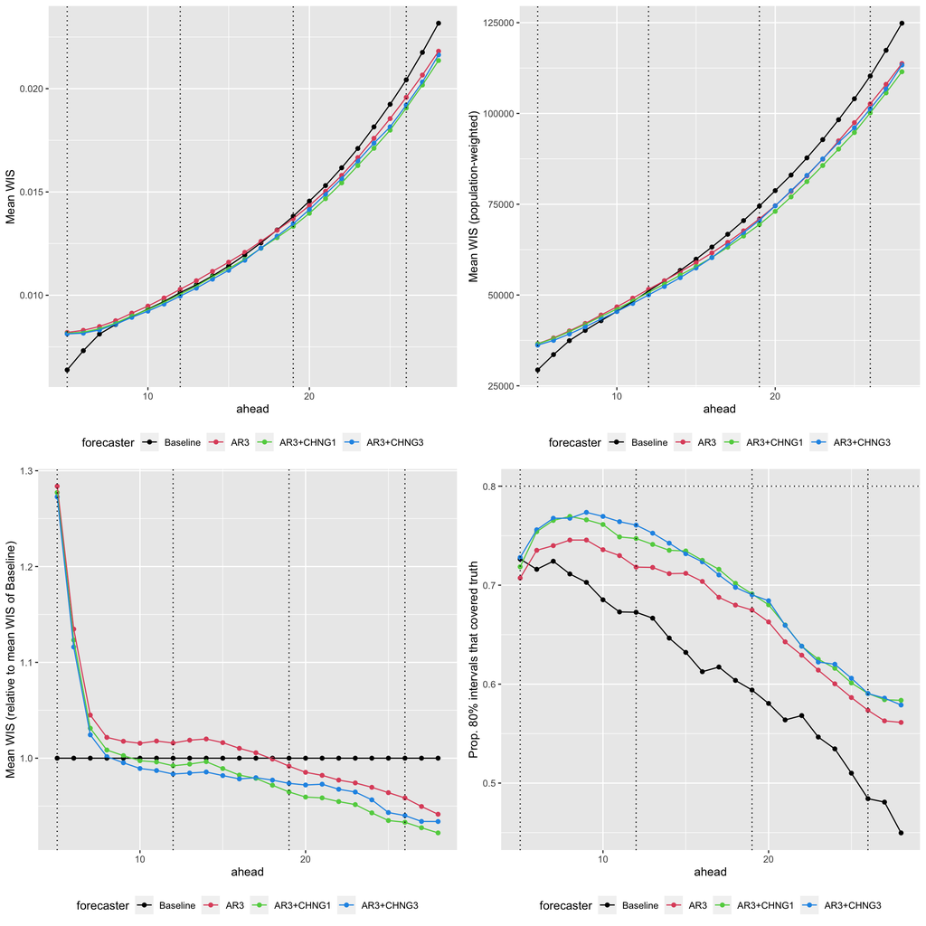

```r
full_results = readRDS('results/results_23.RDS')

results = full_results %>% filter (
      !stringr::str_ends(forecaster, '_7'),
      !stringr::str_detect(forecaster, 'logtrans'),
    ) %>% mutate (
      forecaster=stringr::str_replace(forecaster, '_23', ''),
    )

state_pop = covidcast::state_census %>% tibble (
    ) %>% transmute (
      geo_value = stringr::str_to_lower(ABBR),
      pop = POPESTIMATE2019,
    ) %>% mutate (
      state_with_pop = sprintf('%s, %d', geo_value, pop),
      state_with_pop = factor(state_with_pop,
                      levels = state_with_pop[order(pop)])
    )


results = results %>% left_join (
      state_pop,
      by='geo_value',
    ) %>% mutate (
      pop_wis = wis * pop,
      pop_ae = ae * pop,
    )

results$forecaster = factor(results$forecaster,
                            levels=c('Baseline','AR3','AR3+CHNG1','AR3+CHNG3'))

mean_results = results %>% group_by (
        forecaster,
        ahead,
      ) %>% summarize (
        mean_wis = mean(wis),
        mean_pop_wis = mean(pop_wis),
        mean_cov80 = mean(cov80),
        median_wis = median(wis),
        median_pop_wis = median(pop_wis),
      ) %>% ungroup
relative_mean = inner_join (
      mean_results %>% filter (
        forecaster == 'Baseline'
      ) %>% select (
        -forecaster,
      ),
      mean_results,
      by=c('ahead'),
      suffix=c('_Baseline', '')
    ) %>% transmute (
      ahead,
      forecaster,
      relative_mean_wis = mean_wis/mean_wis_Baseline,
      relative_median_wis = median_wis/median_wis_Baseline,
    )

plt_mean_wis = mean_results %>% ggplot (
      aes(x=ahead,
          y=mean_wis,
          color=forecaster)
    ) + geom_point (
    ) + geom_line (
    ) + scale_color_manual(
      values=colors,
    ) + geom_vline (
      xintercept=c(5, 12, 19, 26),
      linetype='dotted',
    ) + ylab (
      'Mean WIS'
    ) + theme(
      legend.position="bottom"
    )

plt_mean_pop_wis = mean_results %>% ggplot (
      aes(x=ahead,
          y=mean_pop_wis,
          color=forecaster)
    ) + geom_point (
    ) + geom_line (
    ) + scale_color_manual(
      values=colors,
    ) + geom_vline (
      xintercept=c(5, 12, 19, 26),
      linetype='dotted',
    ) + ylab (
      'Mean WIS (population-weighted)'
    ) + theme(
      legend.position="bottom"
    )

plt_relative_mean = relative_mean %>% ggplot (
      aes(x=ahead,
          y=relative_mean_wis,
          color=forecaster)
    ) + geom_point (
    ) + geom_line (
    ) + scale_color_manual(
      values=colors,
    ) + geom_vline (
      xintercept=c(5, 12, 19, 26),
      linetype='dotted',
    ) + ylab (
      'Mean WIS (relative to mean WIS of Baseline)'
    ) + theme(
      legend.position="bottom"
    )

plt_cov80 = mean_results %>% ggplot (
      aes(x=ahead,
          y=mean_cov80,
          color=forecaster)
    ) + geom_point (
    ) + geom_line (
    ) + scale_color_manual(
      values=colors,
    ) + geom_vline (
      xintercept=c(5, 12, 19, 26),
      linetype='dotted',
    ) + geom_hline (
      yintercept=0.8,
      linetype='dotted',
    ) + ylab (
      'Prop. 80% intervals that covered truth'
    ) + theme(
      legend.position="bottom"
    )

gridExtra::grid.arrange(plt_mean_wis,
                        plt_mean_pop_wis,
                        plt_relative_mean,
                        plt_cov80,
                        nrow=2)
```

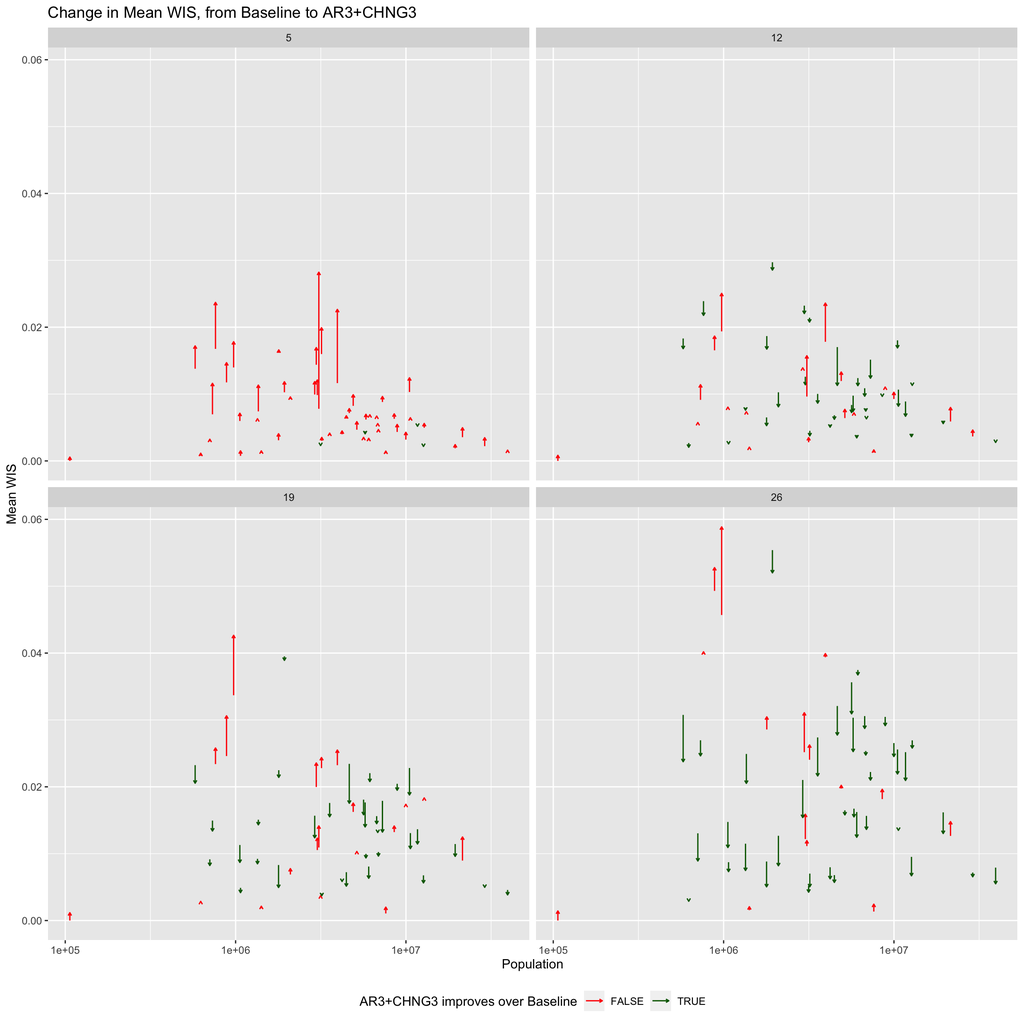

```r
results_diff = results %>% filter (
      ahead %in% c(5, 12, 19, 26),
      forecaster %in% c('Baseline', 'AR3+CHNG3'),
    ) %>% group_by (
      geo_value,
      ahead,
      forecaster,
    ) %>% summarize (
      mean_wis = mean(wis),
      mean_cov80 = mean(cov80),
    ) %>% ungroup (
    ) %>% inner_join (
      state_pop,
      by='geo_value',
    )
joined_results_diff = inner_join (
      results_diff %>% filter (
        forecaster == 'Baseline',
      ) %>% select (
        -forecaster,
        -state_with_pop,
      ),
      results_diff %>% filter (
        forecaster == 'AR3+CHNG3',
      ) %>% select (
        -forecaster,
        -state_with_pop,
        -pop,
      ),
      by=c('geo_value', 'ahead'),
      suffix=c('_Baseline', '_AC3')
    ) %>% mutate (
      improved_mean_wis = mean_wis_AC3 <= mean_wis_Baseline,
      improved_mean_cov80 = mean_cov80_AC3 >= mean_cov80_Baseline,
    )

plt = ggplot(joined_results_diff,
             aes(x=pop,
                 y=mean_wis_Baseline,
                 xend=pop,
                 yend=mean_wis_AC3,
                 color=improved_mean_wis),
    ) + geom_segment(
      arrow=arrow(length=unit(0.1, 'cm')),
    ) + scale_color_manual (
      values = c(1, 4),
    ) + scale_color_manual(
      values=c('red', 'darkgreen'),
      name='AR3+CHNG3 improves over Baseline',
    ) + facet_wrap (
      vars(ahead),
      nrow=2
    ) + xlab (
      'Population'
    ) + ylab (
      'Mean WIS'
    ) + ggtitle (
      'Change in Mean WIS, from Baseline to AR3+CHNG3'
    ) + scale_x_log10 (
    ) + theme (
      legend.position='bottom',
    )

plt
```

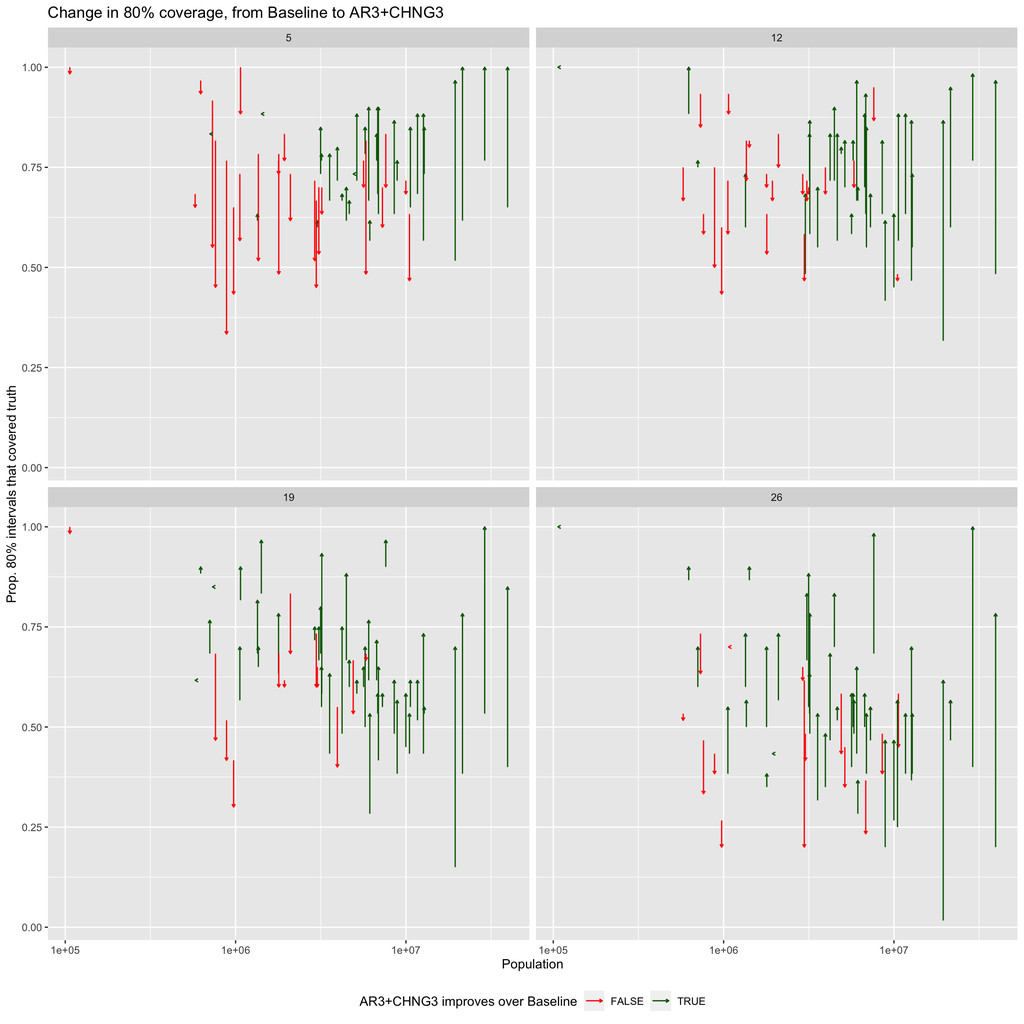

```r
plt = ggplot(joined_results_diff,
             aes(x=pop,
                 y=mean_cov80_Baseline,
                 xend=pop,
                 yend=mean_cov80_AC3,
                 color=improved_mean_cov80),
    ) + geom_segment(
      arrow=arrow(length=unit(0.1, 'cm')),
    ) + scale_color_manual (
      values = c(1, 4),
    ) + scale_color_manual(
      values=c('red', 'darkgreen'),
      name='AR3+CHNG3 improves over Baseline',
    ) + facet_wrap (
      vars(ahead),
      nrow=2
    ) + xlab (
      'Population'
    ) + ylab (
      'Prop. 80% intervals that covered truth'
    ) + ggtitle (
      'Change in 80% coverage, from Baseline to AR3+CHNG3'
    ) + scale_x_log10 (
    ) + theme (
      legend.position='bottom',
    )

plt
```